# GLM Model Exercise

# Introduction to GLM Model Fitting

In this activity, you’ll practice fitting various types of Generalized Linear Models (GLMs) using both frequentist approaches (`lm()`, `glm()`) and Bayesian approaches (`brms`).

## Worked Example: Simple Linear Regression

Let’s start with a simple example to demonstrate both `lm()` and `brms()`

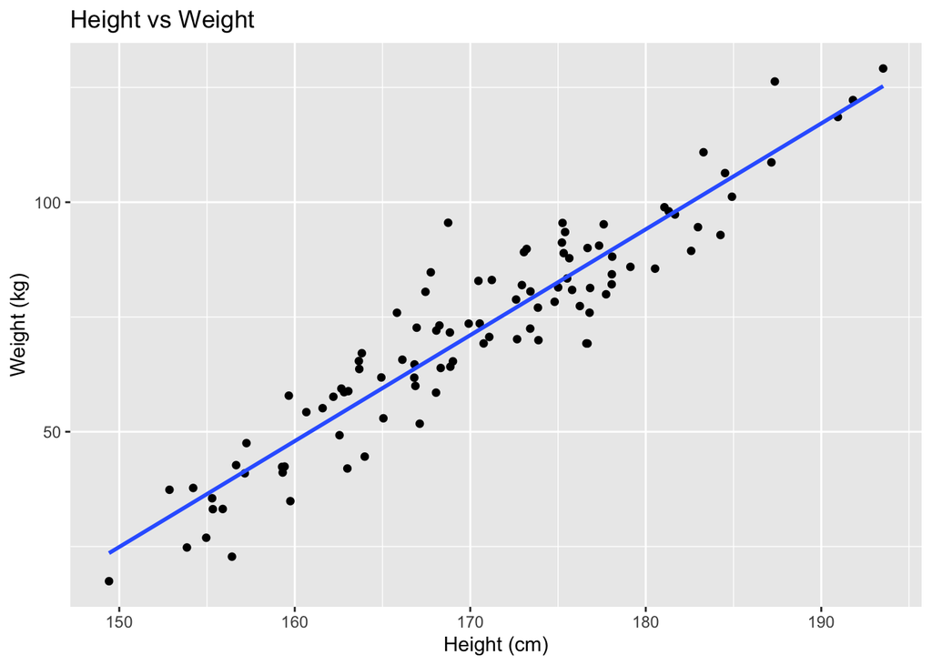

```r
# Simple example: Height vs Weight
n <- 100
height_cm <- rnorm(n, mean = 170, sd = 10)
weight_kg <- 2.3 * height_cm - 320 + rnorm(n, mean = 0, sd = 8)
example_data <- data.frame(height_cm, weight_kg)

# Visualize
ggplot(example_data, aes(x = height_cm, y = weight_kg)) +
  geom_point() +
  geom_smooth(method = "lm", se = FALSE) +
  labs(title = "Height vs Weight", x = "Height (cm)", y = "Weight (kg)")
```

**Frequentist approach using lm():**

```r
# Fit linear model
model_lm <- lm(weight_kg ~ height_cm, data = example_data)
summary(model_lm)
```

```
##
## Call:
## lm(formula = weight_kg ~ height_cm, data = example_data)
##
## Residuals:
##      Min       1Q   Median       3Q      Max
## -17.2224  -5.3770  -0.4193   4.9142  27.4010
##
## Coefficients:
##               Estimate Std. Error t value Pr(>|t|)
## (Intercept) -321.04739   14.87595  -21.58   <2e-16 ***
## height_cm      2.30635    0.08719   26.45   <2e-16 ***
## ---
## Signif. codes:  0 '***' 0.001 '**' 0.01 '*' 0.05 '.' 0.1 ' ' 1
##
## Residual standard error: 8.216 on 98 degrees of freedom
## Multiple R-squared:  0.8771, Adjusted R-squared:  0.8759
## F-statistic: 699.7 on 1 and 98 DF,  p-value: < 2.2e-16
```

**Bayesian approach using brms:**

```r
# Fit Bayesian linear model
model_brms <- brm(weight_kg ~ height_cm,
                  data = example_data,
                  family = gaussian(),
                  chains = 2,
                  iter = 2000,
                  refresh = 0)  # suppress output
```

```
## Trying to compile a simple C file
```

```r
summary(model_brms)
```

```
##  Family: gaussian
##   Links: mu = identity
## Formula: weight_kg ~ height_cm
##    Data: example_data (Number of observations: 100)
##   Draws: 2 chains, each with iter = 2000; warmup = 1000; thin = 1;
##          total post-warmup draws = 2000
##
## Regression Coefficients:
##           Estimate Est.Error l-95% CI u-95% CI Rhat Bulk_ESS Tail_ESS
## Intercept  -320.81     15.10  -350.84  -290.89 1.00     2289     1397
## height_cm     2.31      0.09     2.13     2.49 1.00     2289     1459
##
## Further Distributional Parameters:
##       Estimate Est.Error l-95% CI u-95% CI Rhat Bulk_ESS Tail_ESS
## sigma     8.30      0.60     7.21     9.50 1.00     2193     1520
##
## Draws were sampled using sampling(NUTS). For each parameter, Bulk_ESS
## and Tail_ESS are effective sample size measures, and Rhat is the potential
## scale reduction factor on split chains (at convergence, Rhat = 1).
```

## Data Generation

The code below generates your datasets for the next part of the activity.

```r
# Set seed for reproducibility
set.seed(540)

# Dataset 1: Student Test Scores (Linear Regression)
n1 <- 200
study_hours <- runif(n1, 0, 10)
test_score <- 65 + 3.2 * study_hours + rnorm(n1, 0, 8)
test_score <- pmax(0, pmin(100, test_score))  # bound between 0-100
dataset1 <- data.frame(
  study_hours = study_hours,
  test_score = test_score
)

# Dataset 2: Medical Treatment Success (Logistic Regression)
n2 <- 300
age <- rnorm(n2, 50, 15)
age <- pmax(18, pmin(85, age))
dosage_mg <- runif(n2, 10, 100)
logit_p <- -2 + 0.02 * age + 0.03 * dosage_mg
prob_success <- plogis(logit_p)
treatment_success <- rbinom(n2, 1, prob_success)
dataset2 <- data.frame(
  age = age,
  dosage_mg = dosage_mg,
  treatment_success = treatment_success
)

# Dataset 3: Exam Performance Proportion (Beta Regression)
n3 <- 150
prep_time <- runif(n3, 1, 20)
difficulty <- factor(sample(c("Easy", "Medium", "Hard"), n3, replace = TRUE))
difficulty_num <- as.numeric(difficulty)
mu_logit <- -1 + 0.15 * prep_time - 0.3 * difficulty_num
mu <- plogis(mu_logit)
# Simulate beta distribution
phi <- 15  # precision parameter
alpha <- mu * phi
beta <- (1 - mu) * phi
exam_proportion <- rbeta(n3, alpha, beta)
dataset3 <- data.frame(
  prep_time = prep_time,
  difficulty = difficulty,
  exam_proportion = exam_proportion
)

# Dataset 4: Hospital Admissions Count (Poisson Regression)
n4 <- 100
population_thousands <- runif(n4, 10, 200)
hospital_quality <- rnorm(n4, 0, 1)
lambda <- exp(1.5 + 0.01 * population_thousands + 0.2 * hospital_quality)
daily_admissions <- rpois(n4, lambda)
dataset4 <- data.frame(
  population_thousands = population_thousands,
  hospital_quality = hospital_quality,
  daily_admissions = daily_admissions
)

# Dataset 5: Customer Satisfaction (Ordered Logistic Regression)
n5 <- 400
service_rating <- rnorm(n5, 7, 2)
service_rating <- pmax(1, pmin(10, service_rating))
price_satisfaction <- rnorm(n5, 6, 1.5)
price_satisfaction <- pmax(1, pmin(10, price_satisfaction))

# Create ordered satisfaction levels
linear_pred <- -2 + 0.3 * service_rating + 0.4 * price_satisfaction
# Convert to ordered categories (1 = Very Unsatisfied, 5 = Very Satisfied)
# Create cumulative probabilities for 5 categories
thresholds <- c(-2, -1, 0, 1)
probs <- plogis(linear_pred)
satisfaction <- rep(1, n5)
for(i in 1:length(thresholds)) {
  satisfaction[linear_pred > thresholds[i]] <- i + 1
}
satisfaction <- pmin(satisfaction, 5)  # cap at 5

dataset5 <- data.frame(
  service_rating = service_rating,
  price_satisfaction = price_satisfaction,
  satisfaction = satisfaction
)

# Dataset 6: Website Click Counts (Negative Binomial Regression)
n6 <- 120
ad_spend_hundreds <- runif(n6, 1, 50)
website_age_years <- runif(n6, 0.5, 5)
mu <- exp(2 + 0.04 * ad_spend_hundreds - 0.15 * website_age_years)
daily_clicks <- rnbinom(n6, size = 5, mu = mu)  # overdispersed count data
dataset6 <- data.frame(
  ad_spend_hundreds = ad_spend_hundreds,
  website_age_years = website_age_years,
  daily_clicks = daily_clicks
)
```

# Exercise 1: Student Test Scores

**Data:** This dataset contains information about students’ study habits and test performance.

- `study_hours`: Number of hours spent studying (0-10)
- `test_score`: Final test score (0-100)

```r
head(dataset1)
```

```
##   study_hours test_score
## 1   0.5320795   57.62465
## 2   8.4054965   94.55855
## 3   7.6853594   88.97212
## 4   3.5665075   75.34118
## 5   9.8189897  100.00000
## 6   3.8671707   71.16481
```

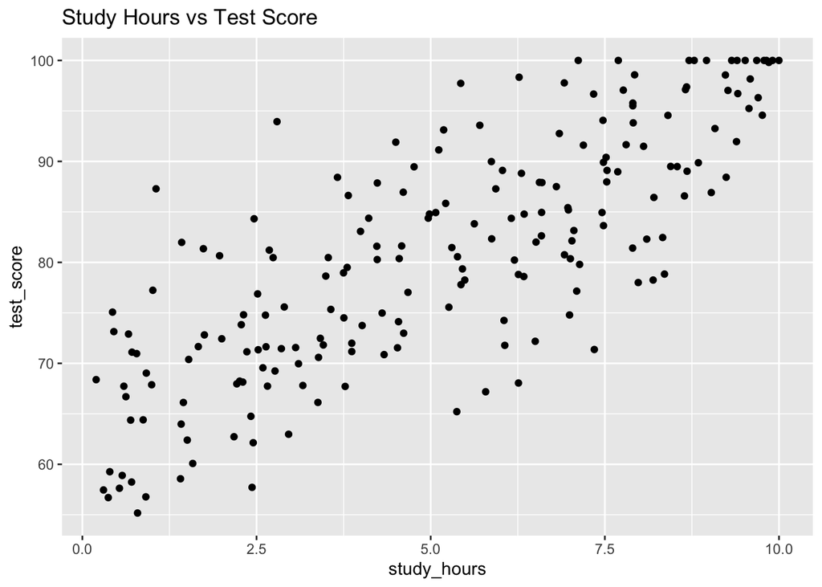

```r
ggplot(dataset1, aes(x = study_hours, y = test_score)) +
  geom_point() +
  labs(title = "Study Hours vs Test Score")
```

**Question:** How does study time relate to test performance?

After the 7.5 hour mark you can confirm at minimum getting a 75% on the test. Zero studying will at minimum scor a 55%~

# Exercise 2: Medical Treatment Success

**Data:** This dataset tracks medical treatment outcomes.

- `age`: Patient age in years (18-85)
- `dosage_mg`: Treatment dosage in milligrams (10-100)
- `treatment_success`: Binary outcome (1 = success, 0 = failure)

```r
head(dataset2)
```

```
##        age dosage_mg treatment_success
## 1 42.29533  38.80757                 1
## 2 48.74681  83.59977                 1
## 3 44.74358  90.60622                 1
## 4 45.26885  83.11789                 1
## 5 66.05802  93.79013                 1
## 6 50.89959  69.31659                 0
```

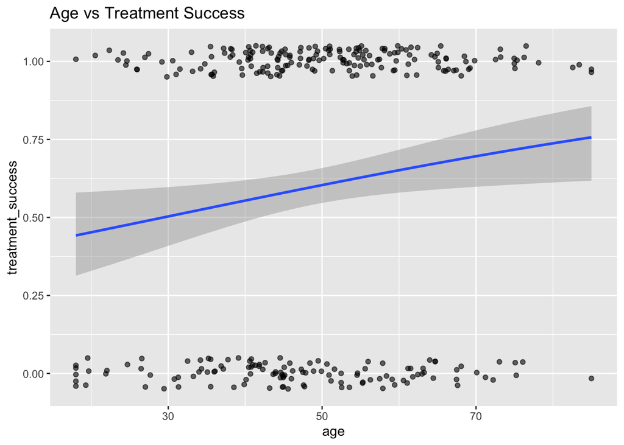

```r
ggplot(dataset2, aes(x = age, y = treatment_success)) +
  geom_jitter(height = 0.05, alpha = 0.6) +
  geom_smooth(method = "glm", method.args = list(family = "binomial")) +
  labs(title = "Age vs Treatment Success")
```

**Questions:** 1. How do age and dosage affect treatment success probability?

# Exercise 3: Exam Performance Proportions

**Data:** This dataset contains exam performance as proportions (0-1).

- `prep_time`: Hours of preparation (1-20)
- `difficulty`: Exam difficulty level (Easy, Medium, Hard)
- `exam_proportion`: Proportion of exam answered correctly (0-1)

```r
head(dataset3)
```

```
##   prep_time difficulty exam_proportion
## 1 10.392144     Medium       0.4633412
## 2 18.795892       Hard       0.8554437
## 3  8.582044     Medium       0.4488297
## 4  7.709924       Hard       0.6428585
## 5  9.441334       Easy       0.3358493
## 6 10.324245     Medium       0.4586421
```

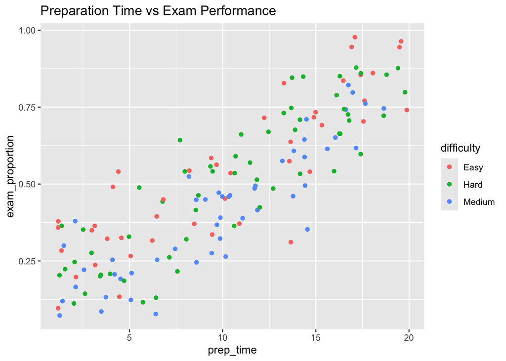

```r
ggplot(dataset3, aes(x = prep_time, y = exam_proportion, color = difficulty)) +
  geom_point() +
  labs(title = "Preparation Time vs Exam Performance")
```

**Questions:** 1. How do preparation time and exam difficulty affect performance?

# Exercise 4: Hospital Daily Admissions

**Data Description:** This dataset tracks daily hospital admissions.

- `population_thousands`: Local population in thousands (10-200)
- `hospital_quality`: Hospital quality rating (standardized, mean=0)
- `daily_admissions`: Count of daily admissions

```r
head(dataset4)
```

```
##   population_thousands hospital_quality daily_admissions
## 1             37.63419       -1.0359215               11
## 2             21.80080       -2.6324886                1
## 3            130.18607       -1.2872713               13
## 4             58.72609       -0.6921662                7
## 5             42.54236        0.7215376                6
## 6             88.06270        1.4891312               11
```

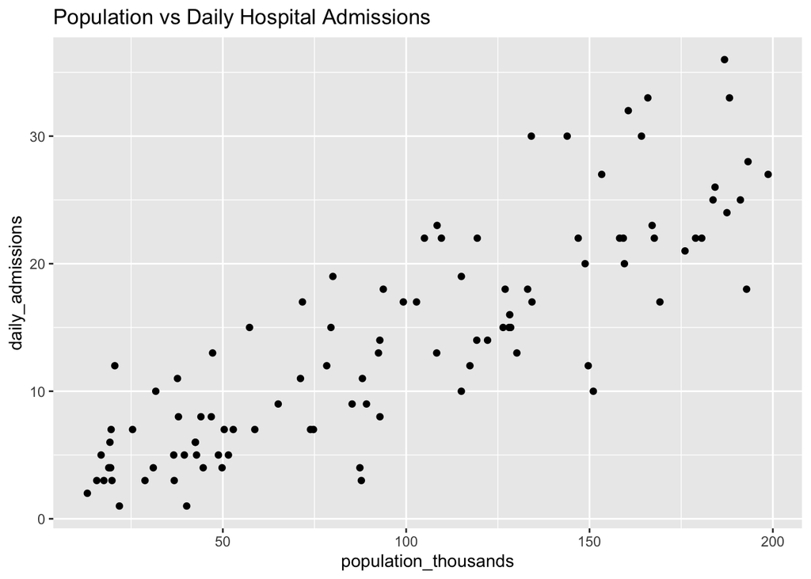

```r
ggplot(dataset4, aes(x = population_thousands, y = daily_admissions)) +
  geom_point() +
  labs(title = "Population vs Daily Hospital Admissions")
```

**Questions:** 1. How do population size and hospital quality affect admission counts?

# Exercise 5: Customer Satisfaction

**Data Description:** This dataset contains customer satisfaction ratings.

- `service_rating`: Service quality rating (1-10)
- `price_satisfaction`: Price satisfaction rating (1-10)
- `satisfaction`: Overall satisfaction (1=Very Unsatisfied, 5=Very Satisfied)

```r
head(dataset5)
```

```
##   service_rating price_satisfaction satisfaction
## 1       7.048679           4.100683            5
## 2       3.267410           6.762802            5
## 3       7.414587           4.963177            5
## 4       5.949857           6.382300            5
## 5       5.562775           5.139219            5
## 6       4.633100           7.312814            5
```

```r
table(dataset5$satisfaction)
```

```
##
##   3   4   5
##   1  14 385
```

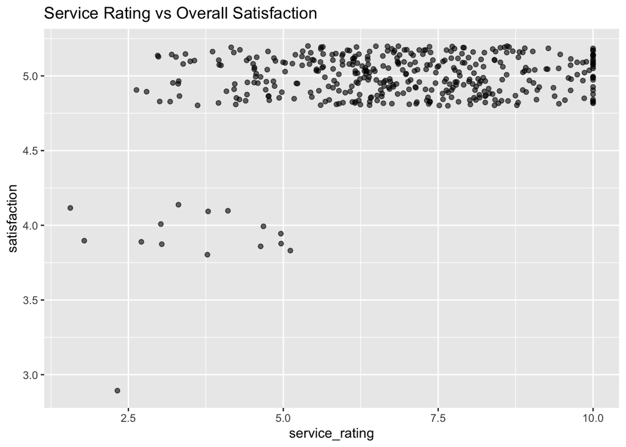

```r
ggplot(dataset5, aes(x = service_rating, y = satisfaction)) +
  geom_jitter(height = 0.2, alpha = 0.6) +
  labs(title = "Service Rating vs Overall Satisfaction")
```

**Questions:** 1. How do service rating and price satisfaction predict overall satisfaction?

# Exercise 6: Website Daily Clicks

**Data Description:** This dataset tracks website click counts (potentially overdispersed👀).

- `ad_spend_hundreds`: Advertising spend in hundreds of dollars (1-50)
- `website_age_years`: Age of website in years (0.5-5)
- `daily_clicks`: Count of daily clicks

```r
head(dataset6)
```

```
##   ad_spend_hundreds website_age_years daily_clicks
## 1          2.255721         3.6169609            9
## 2         12.386022         3.1416621            6
## 3         21.929503         3.9189274           22
## 4         42.016737         2.6527501           51
## 5          2.670888         0.6182084            9
## 6         24.933719         3.3780597           11
```

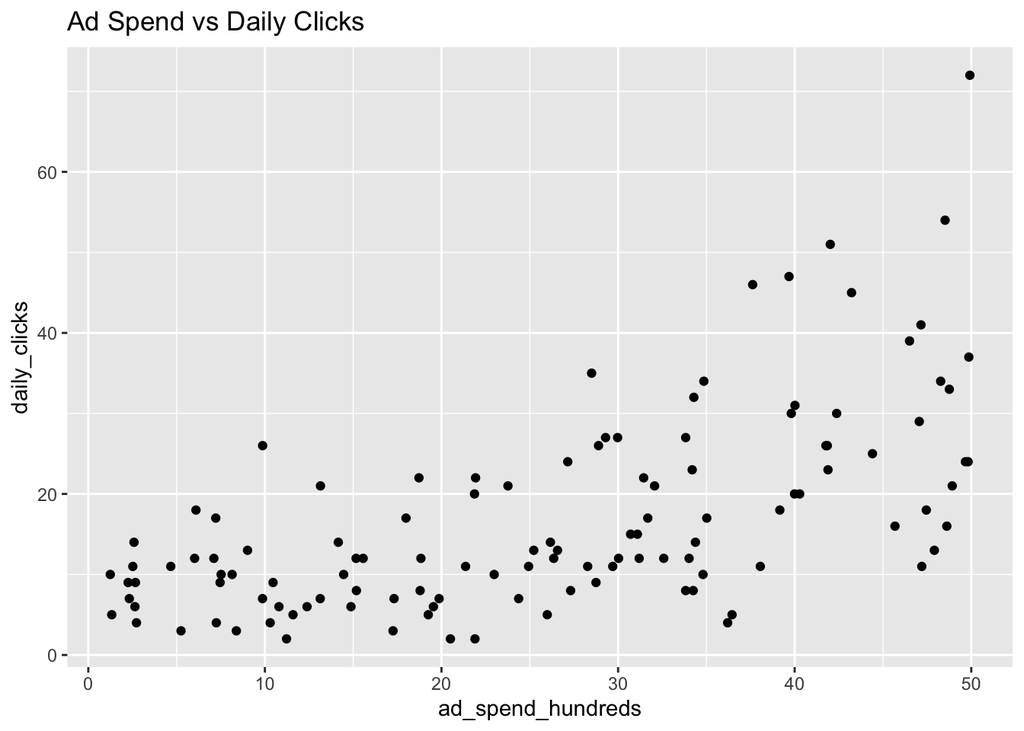

```r
ggplot(dataset6, aes(x = ad_spend_hundreds, y = daily_clicks)) +
  geom_point() +
  labs(title = "Ad Spend vs Daily Clicks")
```

```r
# Check for overdispersion
mean(dataset6$daily_clicks)
```

```
## [1] 16.925
```

```r
var(dataset6$daily_clicks)
```

```
## [1] 152.9607
```

**Questions:** 1. How do advertising spend and website age affect click counts?